# Exercise 13

13E3. Rewrite the following model as a multilevel model.

```
    yi~Normal(mui, sigma)
    mui=alphagroup[i] + beta*xi
    alphagroup[i]~Normal(0,5)
    beta~Normal(0,1)
sigma~Exponential(1)

    V

    yi~Normal(mui, sigma)
    mui=alphagroup[i] + beta*xi
    alphagroup[i]~Normal(alphaMean,sigmaH)
    alphaMean~Normal(0,5)
    beta~Normal(0,1)
sigma~Exponential(1)
sigmaH~Exponential(1)
```

13M1. Revisit the Reed frog survival data, data(reedfrogs), and add the predation and size treatment variables to the varying intercepts model. Consider models with either main effect alone, both main effects, as well as a model including both and their interaction. Instead of focusing on inferences about these two predictor variables, focus on the inferred variation across tanks. Explain why it changes as it does across models.

First,let’s setup the datalist: We are creating two categorical variables for pred and size_

```r
library(rethinking)
data(reedfrogs)
d <- reedfrogs
dat <- list(
    S = d$surv,
    n = d$density,
    tank = 1:nrow(d),
    pred = ifelse( d$pred=="no" , 0L , 1L ),
    size_ = ifelse( d$size=="small" , 1L , 2L )
)
```

Now to define a series of models. The first is just the varying intercepts model from the text:

```r
m1.1 <- ulam(
    alist(
        S ~ binomial( n , p ),
        logit(p) <- a[tank],
        a[tank] ~ normal( a_bar , sigma ),
        a_bar ~ normal( 0 , 1.5 ),
        sigma ~ exponential( 1 )
    ), data=dat , chains=4 , cores=4 , log_lik=TRUE )
```

[output not shown]

[output not shown]

[output not shown]

[output not shown]

[output not shown]

The other models just incorporate the predictors, as ordinary regression terms.

First, adding predation

```r
m1.2 <- ulam(
    alist(
        S ~ binomial( n , p ),
        logit(p) <- a[tank] + bp*pred,
        a[tank] ~ normal( a_bar , sigma ),
        bp ~ normal( -0.5 , 1 ),
        a_bar ~ normal( 0 , 1.5 ),
        sigma ~ exponential( 1 )
    ), data=dat , chains=4 , cores=4 , log_lik=TRUE )
```

[output not shown]

[output not shown]

[output not shown]

[output not shown]

[output not shown]

[output not shown]

[output not shown]

[output not shown]

[output not shown]

```
## Chain 2
```

[output not shown]

[output not shown]

[output not shown]

[output not shown]

[output not shown]

```
## Chain 3
```

[output not shown]

[output not shown]

[output not shown]

[output not shown]

[output not shown]

```
## Chain 4
```

[output not shown]

Next, size

```r
m1.3 <- ulam(
    alist(
        S ~ binomial( n , p ),
        logit(p) <- a[tank] + s[size_],
        a[tank] ~ normal( a_bar , sigma ),
        s[size_] ~ normal( 0 , 0.5 ),
        a_bar ~ normal( 0 , 1.5 ),
        sigma ~ exponential( 1 )
    ), data=dat , chains=4 , cores=4 , log_lik=TRUE )
```

[output not shown]

[output not shown]

[output not shown]

[output not shown]

[output not shown]

[output not shown]

[output not shown]

[output not shown]

[output not shown]

```
## Chain 1
```

[output not shown]

Now, both Predation + size

```r
m1.4 <- ulam(
    alist(
        S ~ binomial( n , p ),
        logit(p) <- a[tank] + bp*pred + s[size_],
        a[tank] ~ normal( a_bar , sigma ),
        bp ~ normal( -0.5 , 1 ),
        s[size_] ~ normal( 0 , 0.5 ),
        a_bar ~ normal( 0 , 1.5 ),
        sigma ~ exponential( 1 )
    ), data=dat , chains=4 , cores=4 , log_lik=TRUE )
```

[output not shown]

[output not shown]

[output not shown]

[output not shown]

[output not shown]

[output not shown]

[output not shown]

[output not shown]

[output not shown]

```
## Chain 1
```

[output not shown]

Finally, predation + size + their interaction

```r
m1.5a <- ulam(
    alist(
        S ~ binomial( n , p ),
        logit(p) <- a_bar + a[tank] + bp[size_]*pred + s[size_],
        a[tank] ~ normal( a_bar , sigma ),
        bp[size_] ~ normal( -0.5 , 1 ),
        s[size_] ~ normal( 0 , 0.5 ),
        a_bar ~ normal( 0 , 1.5 ),
        sigma ~ exponential( 1 )
    ), data=dat , chains=4 , cores=4 , log_lik=TRUE )
```

[output not shown]

[output not shown]

[output not shown]

[output not shown]

[output not shown]

[output not shown]

[output not shown]

[output not shown]

[output not shown]

```
## Chain 2
```

[output not shown]

Fitting the same model as above using a non-centered parameterization for the tank effect: z[tank] z[tank] is given a standard normal distribution (0,1). This is then scaled by a factor sigma.

```r
m1.5 <- ulam(
    alist(
        S ~ binomial( n , p ),
        logit(p) <- a_bar + z[tank]*sigma + bp[size_]*pred + s[size_],
        z[tank] ~ normal( 0 , 1 ),
        bp[size_] ~ normal( -0.5 , 1 ),
        s[size_] ~ normal( 0 , 0.5 ),
        a_bar ~ normal( 0 , 1.5 ),
        sigma ~ exponential( 1 )
    ), data=dat , chains=4 , cores=4 , log_lik=TRUE )
```

[output not shown]

[output not shown]

[output not shown]

[output not shown]

[output not shown]

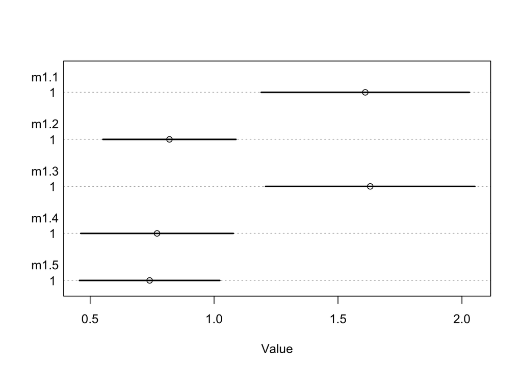

```r
plot( coeftab( m1.1 , m1.2 , m1.3 , m1.4 , m1.5 ), pars="sigma" )
```

The two models that omit predation, m1.1 and m1.3, have larger values of sigma. This is because predation explains some of the variation among tanks. So when you add it to the model, the variation in the tank intercepts gets smaller. We’ll examine this in more detail in a the last problem of this chapter. The general point here is that the model with only intercepts measures the variation among tanks, but does nothing to explain it. As we add treatment variables, the variation should shrink, even though the total variation in the data of course stays the same.